# Boletim COVID-19

NUVE HC-FMUSP

13/04/2020

### Distribuição de pacientes internados conforme status laboratorial

**Tabela 1.**Distribuição de casos conforme unidade de internação e status laboratorial:

|  | *Aguardando Exames (N=28) | *Sem exame na DLC (N=23) | Inválido (N=2) | Negativo (N=132) | Positivo (N=111) | Total (N=296) |
| --- | --- | --- | --- | --- | --- | --- |
| Unidade |  |  |  |  |  |  |
| ENFERMARIA | 7 (25.0%) | 16 (69.6%) | 2 (100%) | 82 (62.1%) | 42 (37.8%) | 149 (50.3%) |
| PS | 0 (0%) | 0 (0%) | 0 (0%) | 0 (0%) | 2 (1.8%) | 2 (0.7%) |
| UTI | 21 (75.0%) | 7 (30.4%) | 0 (0%) | 50 (37.9%) | 67 (60.4%) | 145 (49.0%) |

### Total Acumulado de Internações Relacionadas à COVID

**Figura 1.**Total Acumulado de internações relacionadas à COVID no ICHC por Data

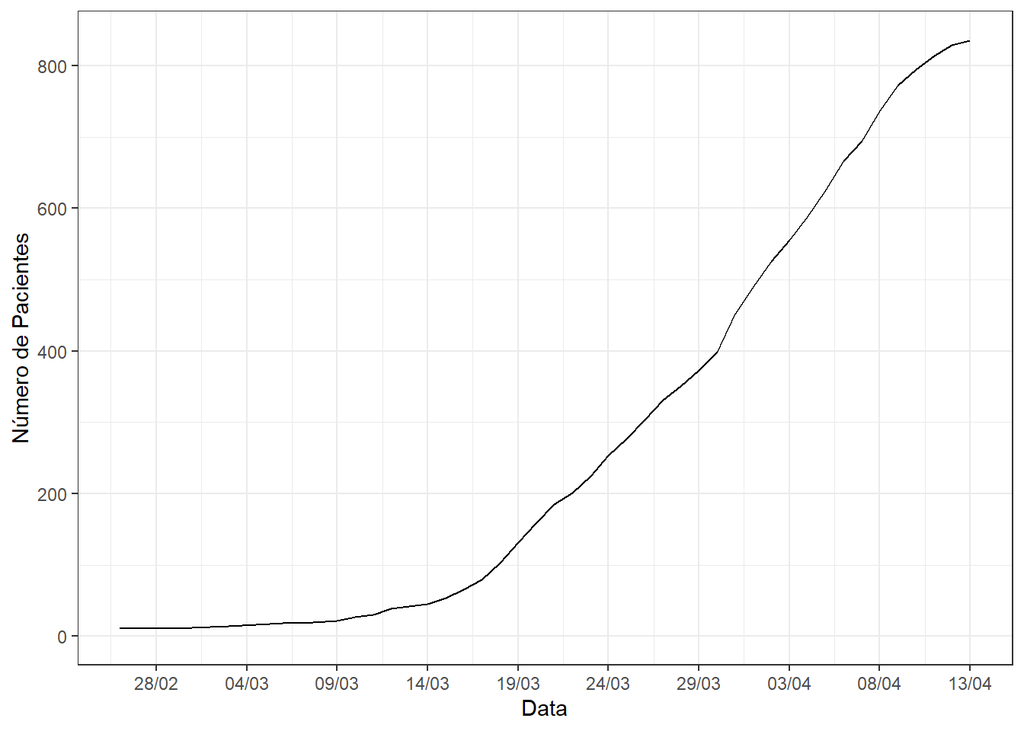

Total acumulado em 13/04/2020 = 835 pacientes

**Figura 2.**Total Internações por instituto relacionadas à SRAG no ICHC por Data

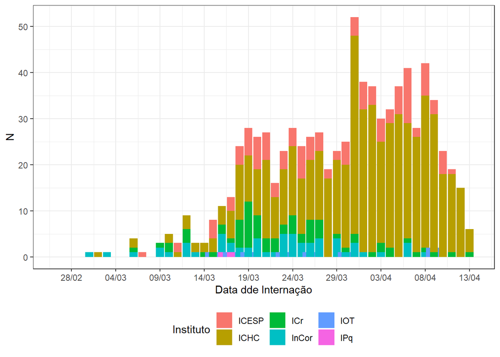

**Figura 3.**Distribuição de casos internados conforme diagnóstico laboratorial e data dos primeiros sintomas

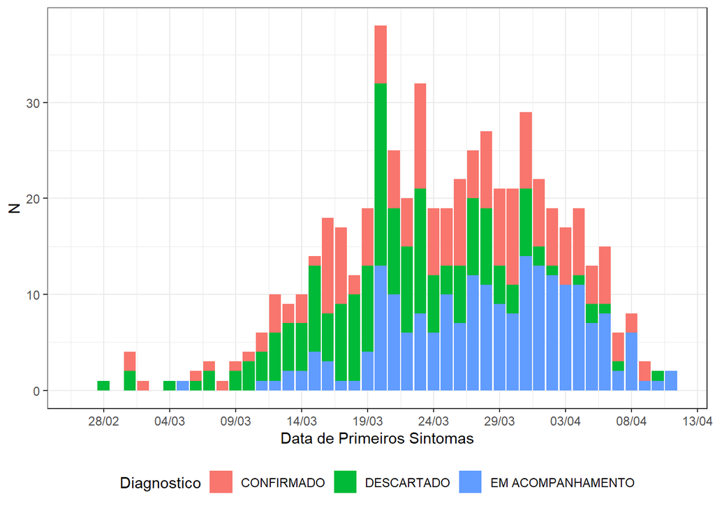

|  | ALTA (N=137) | ÓBITO (N=22) | Sem informação (N=13) | Total (N=172) |
| --- | --- | --- | --- | --- |
| Idade |  |  |  |  |
| Mean (SD) | 39.0 (24.5) | 73.0 (10.3) | 56.4 (19.8) | 44.7 (25.6) |
| Median [Min, Max] | 44.0 [0, 87.0] | 74.0 [55.0, 90.0] | 62.0 [23.0, 85.0] | 49.5 [0, 90.0] |
| Sexo |  |  |  |  |
| F | 70 (51.1%) | 13 (59.1%) | 7 (53.8%) | 90 (52.3%) |
| M | 67 (48.9%) | 9 (40.9%) | 6 (46.2%) | 82 (47.7%) |

**Tabela 3** Diagnóstico final de casos suspeitos de COVID-19 internados no ICHC de acordo com desfecho – HCFMUSP, 2020

|  | ALTA (N=137) | ÓBITO (N=22) | Sem informação (N=13) | Total (N=172) |
| --- | --- | --- | --- | --- |
| Diagnóstico |  |  |  |  |
| CONFIRMADO | 22 (16.1%) | 15 (68.2%) | 1 (7.7%) | 38 (22.1%) |
| DESCARTADO | 115 (83.9%) | 7 (31.8%) | 1 (7.7%) | 123 (71.5%) |
| EM ACOMPANHAMENTO | 0 (0%) | 0 (0%) | 11 (84.6%) | 11 (6.4%) |

**Figura 4** Tempo entre início de sintomas e Diagnóstico Confirmado, pacientes atualmente internados no ICHC – HCFMUSP, 2020

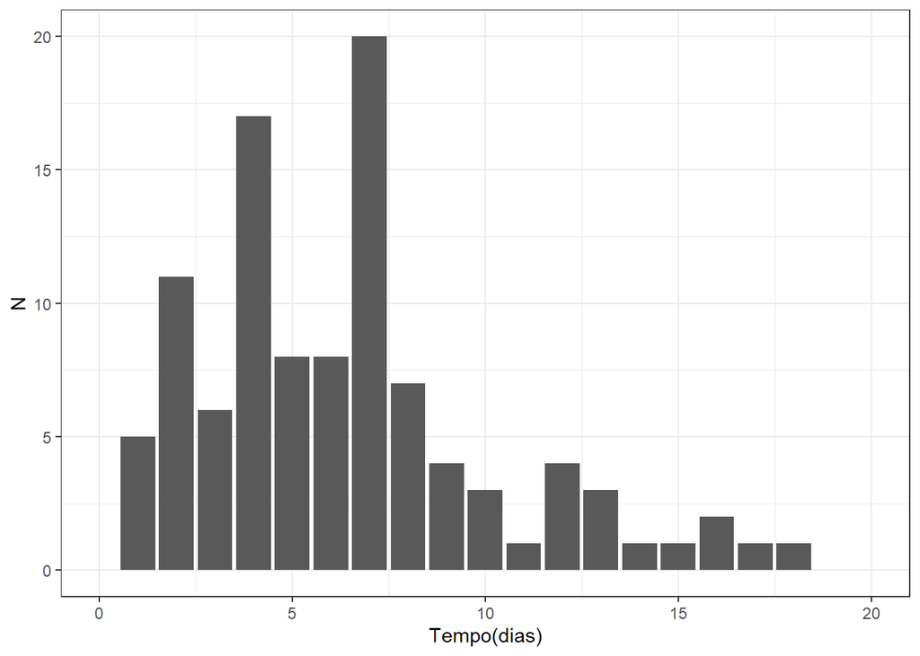

Mediana de tempo entre Primeiros Sintomas e Diagnóstico = 6 dias

**Figura 5** Tempo de internação, pacientes que já sairam do ICHC – HCFMUSP, 2020

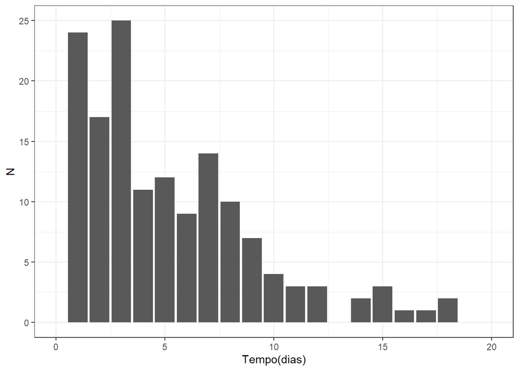

Mediana de tempo de internação (casos encerrados) = 4 dias

Mediana de tempo de internação (casos internados na data do boletim) = 7 dias

**Figura 6** Tipo de Saída por Grupo Etário (casos confirmados)

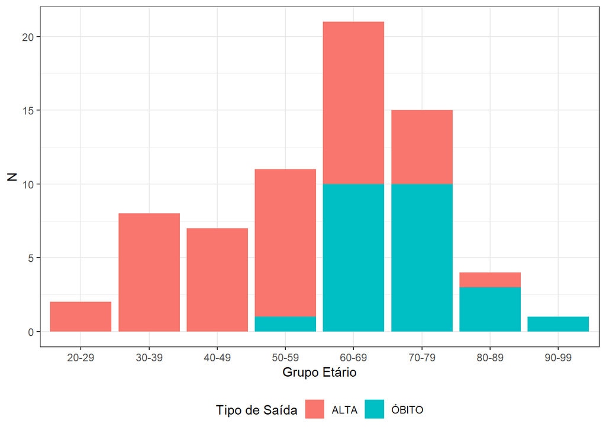